# Deep Learning for Time Series

After fitting both univariate and multivariate traditional models to varying but unsatisfying degrees of success, we will now implement deep learning as a more complex way of modeling data. In this case, we will be using the national ridership data as a target variable for both univariate and multivariate analysis, implementing three different types of models for each input type.

*Note: due to technical limitations of running `Keras` locally, the code blocks shown were run in Google Colab. The subsequent results are copied and pasted from that execution.*

## Univariate Deep Learning Forecasting

### Model Training

To implement univariate deep learning forecasting, we will fit a simple RNN model, an LSTM model, and a GRU model using `Keras` in Python. These models will utilize data that is split into training and validation sets, with the training set representing the first 90% of the data. This percentage split was chosen in order to place the initial impact of COVID-19 in the training set, as it would be less useful to require a model to be able to anticipate a sudden downturn like that than it is to create a model that can predict trends in the recovery.

Additionally, these models implement windowing and reshaping for sequence modeling, as well as regularization and early stopping to prevent overfitting.

The following code shows how the data was prepared and fit, with results below showing statistics and plots that will help us evaluate the performance of each model.

**Data Preparation**

```python
from sklearn.metrics import mean_squared_error,mean_absolute_percentage_error,mean_absolute_error, root_mean_squared_error
from sklearn.preprocessing import MinMaxScaler
from tensorflow.keras.models import Sequential
from tensorflow.keras.layers import LSTM, Dense, Dropout, RNN, GRU, SimpleRNN
from tensorflow.keras.callbacks import EarlyStopping
from tensorflow.keras import initializers
from tensorflow.keras import regularizers
import matplotlib.pyplot as plt
import pandas as pd
import numpy as np
ridership = pd.read_csv("ridership.csv")
```

```python
scaler = MinMaxScaler()
ridership['value_scaled'] = scaler.fit_transform(ridership[['Total Ridership (000s)']])

def create_sequences(series, window_size):
    X, y = [], []
    for i in range(len(series) - window_size):
        X.append(series[i:i+window_size])
        y.append(series[i+window_size])
    return np.array(X), np.array(y)

window_size = 8
series = ridership['value_scaled'].values
X, y = create_sequences(series, window_size)

split_index = int(len(X) * 0.9)
X_train, X_val = X[:split_index], X[split_index:]
y_train, y_val = y[:split_index], y[split_index:]

X_train = X_train.reshape((X_train.shape[0], X_train.shape[1], 1))
X_val = X_val.reshape((X_val.shape[0], X_val.shape[1], 1))

print(X_train.shape)
print(X_val.shape)
print(y_train.shape)
print(y_val.shape)
```

```python
def regression_report(yt,ytp,yv,yvp):
     print("---------- Regression report ----------")

     print("MEAN SQUARED ERROR:")
     print("Train MSE:",mean_squared_error(yt,ytp))
     print("Val MSE:",mean_squared_error(yv,yvp))

     print("MEAN ABSOLUTE ERROR:")
     print("Train MAE:",mean_absolute_error(yt,ytp))
     print("Val MAE:",mean_absolute_error(yv,yvp))

     print("ROOT MEAN SQUARED ERROR:")
     print("Train RMSE:",root_mean_squared_error(yt,ytp))
     print("Val RMSE:",root_mean_squared_error(yv,yvp))


     print("TRAINING:")
     # PARITY PLOT
     fig, ax = plt.subplots()
     ax.plot(yt,ytp,'ro')
     ax.plot(yt,yt,'b-')
     ax.set(xlabel='y_data', ylabel='y_predicted',
         title='Training data parity plot (line y=x represents a perfect fit)')
     plt.show()

     # # PLOT PART OF THE PREDICTED TIME-SERIES
     frac_plot=1.0
     upper=int(frac_plot*yt.shape[0]);
     # print(int(0.5*yt.shape[0]))
     fig, ax = plt.subplots()
     ax.plot(yt[0:upper],'b-')
     ax.plot(ytp[0:upper],'r-',alpha=0.5)
     ax.plot(ytp[0:upper],'ro',alpha=0.25)
     ax.set(xlabel='index', ylabel='y(t (blue=actual & red=prediction)', title='Training: Time-series prediction')
     plt.show()

     print("VALIDATION:")
     # PARITY PLOT
     fig, ax = plt.subplots()
     ax.plot(yv,yvp,'ro')
     ax.plot(yv,yv,'b-')
     ax.set(xlabel='y_data', ylabel='y_predicted',
         title='Validation data parity plot (line y=x represents a perfect fit)')
     plt.show()

     # # PLOT PART OF THE PREDICTED TIME-SERIES
     upper=int(frac_plot*yv.shape[0]);
     fig, ax = plt.subplots()
     ax.plot(yv[0:upper],'b-')
     ax.plot(yvp[0:upper],'r-',alpha=0.5)
     ax.plot(yvp[0:upper],'ro',alpha=0.25)
     ax.set(xlabel='index', ylabel='y(t (blue=actual & red=prediction)', title='Validation: Time-series prediction')
     plt.show()
```

**Simple RNN**

```python
batch_size=X_train.shape[0]
recurrent_hidden_units=8

rnn_model = Sequential()

rnn_model.add(SimpleRNN(
 units=recurrent_hidden_units,
 return_sequences=False,
 input_shape=(window_size, 1),
 recurrent_dropout=0.1,
 recurrent_regularizer=regularizers.L2(0.1),
 activation='relu'))

rnn_model.add(Dense(units=1, activation='linear'))
rnn_model.compile(optimizer='adam', loss='mse')
rnn_model.fit(X_train, y_train, epochs=300, batch_size=4,
               validation_data=(X_val, y_val),
               callbacks=[EarlyStopping(monitor='val_loss', patience=5, restore_best_weights=True)],
               verbose=0)

print(rnn_model.summary())

regression_report(y_train,rnn_model.predict(X_train),y_val,rnn_model.predict(X_val))
```

———- Regression report ———-

MEAN SQUARED ERROR:

- Train MSE: `0.006837816920417588`
- Val MSE: `0.0020229677563443228`

MEAN ABSOLUTE ERROR:

- Train MAE: `0.04165176774639034`
- Val MAE: `0.03384994134309217`

ROOT MEAN SQUARED ERROR:

- Train RMSE: `0.0826910933560416`
- Val RMSE: `0.044977413846777836`

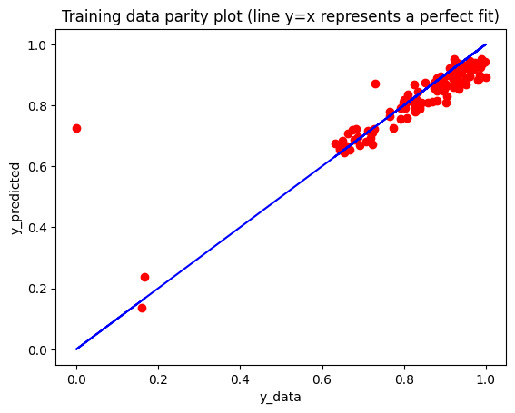

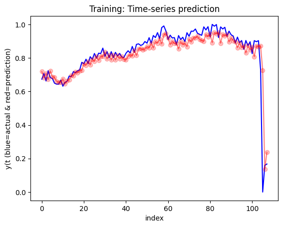

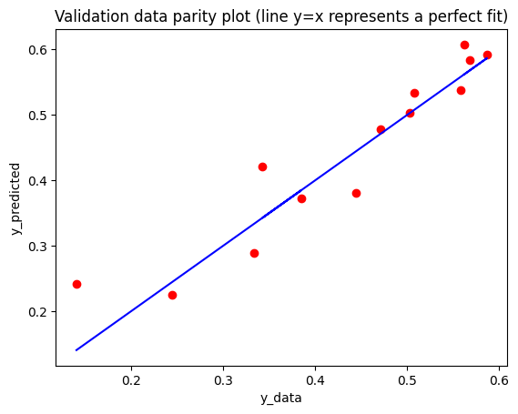

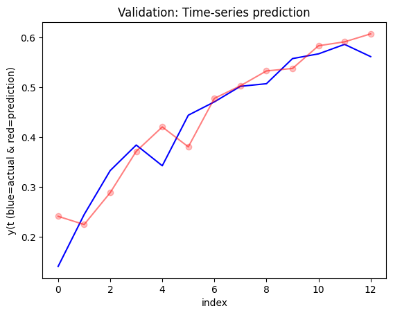

**LSTM**

```python
lstm_model = Sequential()

lstm_model.add(LSTM(
 units=recurrent_hidden_units,
 return_sequences=False,
 input_shape=(window_size, 1),
 recurrent_dropout=0.1,
 recurrent_regularizer=regularizers.L2(0.1),
 activation='relu'))

lstm_model.add(Dense(units=1, activation='linear'))
lstm_model.compile(optimizer='adam', loss='mse')
lstm_model.fit(X_train, y_train, epochs=300, batch_size=4,
               validation_data=(X_val, y_val),
               callbacks=[EarlyStopping(monitor='val_loss', patience=5, restore_best_weights=True)],
               verbose=0)

print(lstm_model.summary())

regression_report(y_train,lstm_model.predict(X_train),y_val,lstm_model.predict(X_val))
```

———- Regression report ———-

MEAN SQUARED ERROR:

- Train MSE: `0.009901040754462664`
- Val MSE: `0.01361178618660799`

MEAN ABSOLUTE ERROR:

- Train MAE: `0.04046624226846958`
- Val MAE: `0.10452379867389218`

ROOT MEAN SQUARED ERROR:

- Train RMSE: `0.09950397356117324`
- Val RMSE: `0.11666955981149492`

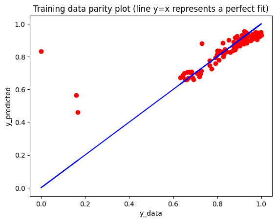

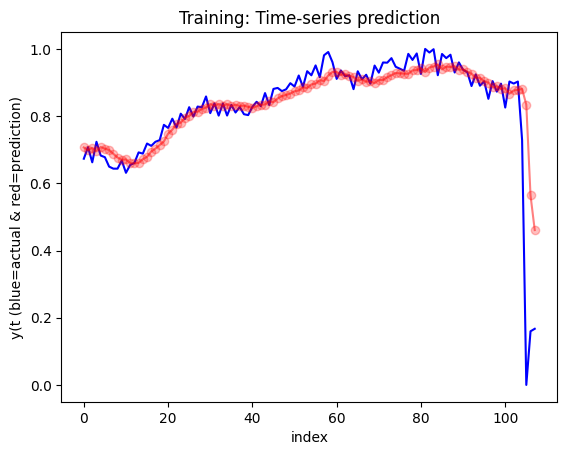

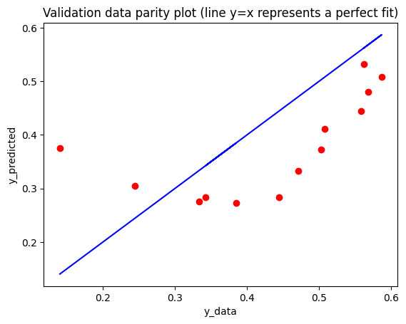

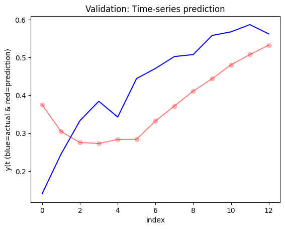

**GRU**

```python
gru_model = Sequential()

gru_model.add(GRU(
 units=recurrent_hidden_units,
 return_sequences=False,
 input_shape=(window_size, 1),
 recurrent_dropout=0.1,
 recurrent_regularizer=regularizers.L2(0.1),
 activation='relu'))

gru_model.add(Dense(units=1, activation='linear'))
gru_model.compile(optimizer='adam', loss='mse')
gru_model.fit(X_train, y_train, epochs=300, batch_size=4,
               validation_data=(X_val, y_val),
               callbacks=[EarlyStopping(monitor='val_loss', patience=5, restore_best_weights=True)],
               verbose=0)

print(gru_model.summary())

regression_report(y_train,gru_model.predict(X_train),y_val,gru_model.predict(X_val))
```

———- Regression report ———-

MEAN SQUARED ERROR:

- Train MSE: `0.007574854708198616`
- Val MSE: `0.0018986130557407863`

MEAN ABSOLUTE ERROR:

- Train MAE: `0.04211270070454647`
- Val MAE: `0.03342054386391111`

ROOT MEAN SQUARED ERROR:

- Train RMSE: `0.08703364124405354`
- Val RMSE: `0.043573077189255134`

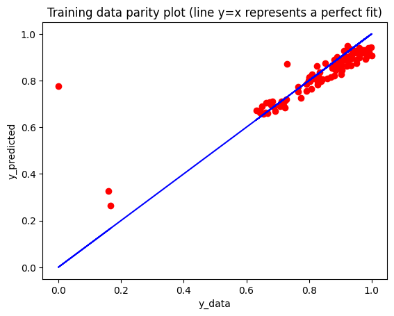

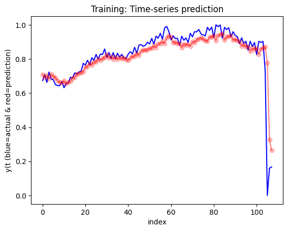

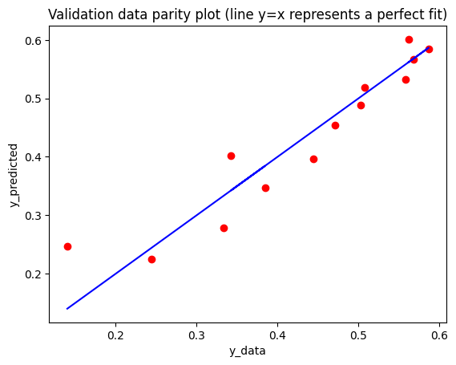

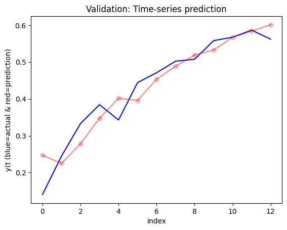

### Analysis and Discussion

Given that we are using root mean squared error (RMSE) on the validation data as the metric to evaluate models, the GRU is the best of the three models, followed by the simple RNN. The LSTM performs significantly worse than both of them. One potential explanation for this is that LSTM models are particularly suited for long-term trends and longer input windows. In this case, there are only 130 observations, making it a relatively small time series that limits these strengths. RNNs and GRUs, on the other hand, are better suited when there are fewer parameters and have a lower risk of overfitting.

Looking at the plots, it’s evident that the RNN and GRU did a good job of fitting predicted values to the increasing slope of the validation data, while also seemingly picking up on the decreasing acceleration of the rebound in public transit ridership. The LSTM had a more difficult time picking up on these nuances.

## Forecasting Performance Reflection

When comparing these results to the traditional univariate forecasting with an ARIMA model, all three of these methods perform better than the traditional one. The difference is not trivial either, with the ARIMA model’s RMSE being more than double that of any deep learning method. The deep learning models appear to better pick up on the fact that after COVID-19 the data rebounds gradually, indicating that the interruption in the time series does not necessarily mean that ridership will continue to decrease.

What this tells us about the dataset is that despite only having 130 observations, which is relatively small for a time series where deep learning is applied, the trends appear to be complex enough that a more computationally demanding method does help to identify nuances. For data that is so affected by COVID-19, yet had clear trends and seasonality both prior to and after that interruption, it is important to fit models that identify different contexts within the time series. Thus, despite the computational cost, it appears that applying deep learning is worthwhile in this case.

The specific model that should be chosen based on these results is the GRU, which had the lowest RMSE. This choice indicates that a more complex method like LSTM is not necessary for this specific set of univariate data. Thus, as long as exceedingly difficult trends arise in the future, this is likely an effective way to forecast public transit ridership.

## Multivariate Deep Learning Forecasting

Now we will move on to multivariate deep learning models by fitting an RNN, LSTM, and GRU on data of a different input type. The variables here will be the same as those used in Model 3 of the Multivariate Time Series Models page. National ridership will be the target variables, with vehicle miles, gas prices, and unemployment rate as predictors.

The following code shows how the data was prepared and fit, with results below showing statistics and plots that will help us evaluate the performance of each model.

### Multivariate Deep Learning Models

**Data Preparation**

```python
data = pd.read_csv("quarterly_combined.csv")
data['ridership'] = data['Total Ridership (000s)']
features = ['ridership', 'vehicle_miles', 'gas_prices', 'unemployment_rate']
data = data[features]
data_scaled = pd.DataFrame(scaler.fit_transform(data), columns=features, index=data.index)

def create_multivariate_sequences(data, target_col, window_size):
    X, y = [], []
    for i in range(len(data) - window_size):
        X.append(data.iloc[i:i+window_size].values)
        y.append(data.iloc[i+window_size][target_col])
    return np.array(X), np.array(y)

window_size = 7
X, y = create_multivariate_sequences(data_scaled, target_col='ridership', window_size=window_size)

# Train/val split
split_idx = int(len(X) * 0.9)
X_train, X_val = X[:split_idx], X[split_idx:]
y_train, y_val = y[:split_idx], y[split_idx:]

print(X_train.shape)
print(X_val.shape)
print(y_train.shape)
print(y_val.shape)
```

**Simple RNN**

```python
rnn_model_mult = Sequential()

rnn_model_mult.add(SimpleRNN(
 units=recurrent_hidden_units,
 return_sequences=False,
 input_shape=(window_size, 4),
 recurrent_dropout=0.1,
 recurrent_regularizer=regularizers.L2(0.1),
 activation='relu'))

rnn_model_mult.add(Dense(units=1, activation='linear'))
rnn_model_mult.compile(optimizer='adam', loss='mse')
rnn_model_mult.fit(X_train, y_train, epochs=300, batch_size=4,
               validation_data=(X_val, y_val),
               callbacks=[EarlyStopping(monitor='val_loss', patience=5, restore_best_weights=True)],
               verbose=0)

print(rnn_model_mult.summary())

regression_report(y_train,rnn_model_mult.predict(X_train),y_val,rnn_model_mult.predict(X_val))
```

———- Regression report ———-

MEAN SQUARED ERROR:

- Train MSE: `0.0069662233510902815`
- Val MSE: `0.01958442359573777`

MEAN ABSOLUTE ERROR:

- Train MAE: `0.043790516158416386`
- Val MAE: `0.12684088757090847`

ROOT MEAN SQUARED ERROR:

- Train RMSE: `0.08346390448026189`
- Val RMSE: `0.1399443589278888`

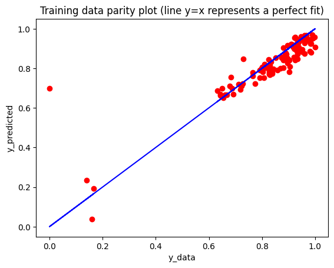

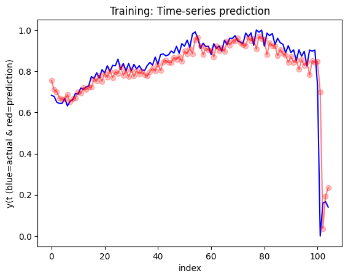

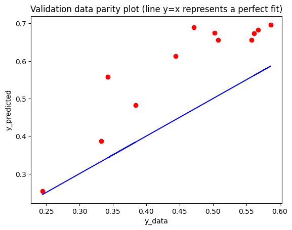

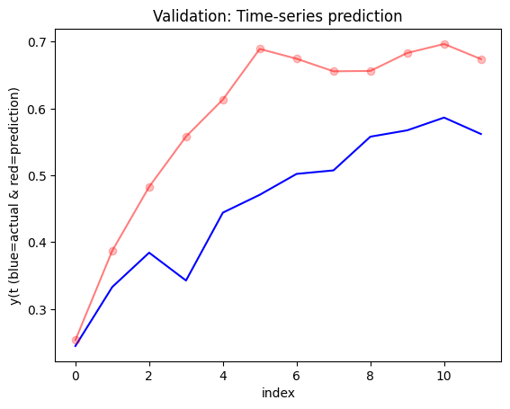

**LSTM**

```python
lstm_model_mult = Sequential()

lstm_model_mult.add(LSTM(
 units=recurrent_hidden_units,
 return_sequences=False,
 input_shape=(window_size, 4),
 recurrent_dropout=0.1,
 recurrent_regularizer=regularizers.L2(0.1),
 activation='relu'))

lstm_model_mult.add(Dense(units=1, activation='linear'))
lstm_model_mult.compile(optimizer='adam', loss='mse')
lstm_model_mult.fit(X_train, y_train, epochs=300, batch_size=4,
               validation_data=(X_val, y_val),
               callbacks=[EarlyStopping(monitor='val_loss', patience=5, restore_best_weights=True)],
               verbose=0)

print(lstm_model_mult.summary())

regression_report(y_train,lstm_model_mult.predict(X_train),y_val,lstm_model_mult.predict(X_val))
```

———- Regression report ———-

MEAN SQUARED ERROR:

- Train MSE: `0.009827871368636193`
- Val MSE: `0.013979126681999523`

MEAN ABSOLUTE ERROR:

- Train MAE: `0.047588444780595006`
- Val MAE: `0.09191082010755441`

ROOT MEAN SQUARED ERROR:

- Train RMSE: `0.0991356210886692`
- Val RMSE: `0.11823335689220502`

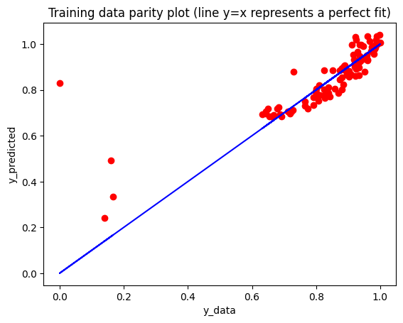

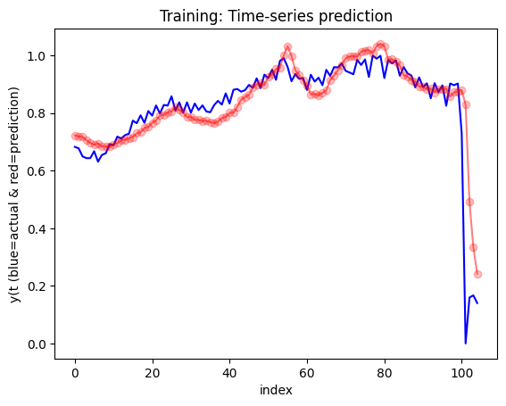

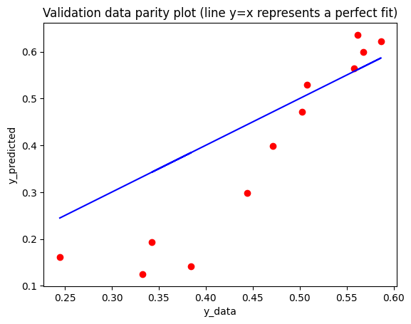

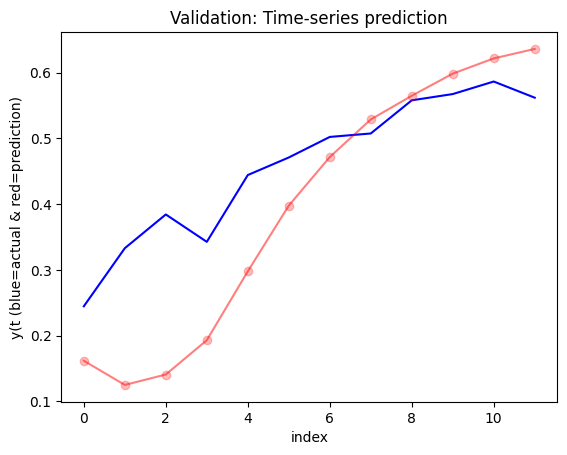

**GRU**

```python
gru_model_mult = Sequential()

gru_model_mult.add(GRU(
 units=recurrent_hidden_units,
 return_sequences=False,
 input_shape=(window_size, 4),
 recurrent_dropout=0.1,
 recurrent_regularizer=regularizers.L2(0.1),
 activation='relu'))

gru_model_mult.add(Dense(units=1, activation='linear'))
gru_model_mult.compile(optimizer='adam', loss='mse')
gru_model_mult.fit(X_train, y_train, epochs=300, batch_size=4,
               validation_data=(X_val, y_val),
               callbacks=[EarlyStopping(monitor='val_loss', patience=5, restore_best_weights=True)],
               verbose=0)

print(gru_model_mult.summary())

regression_report(y_train,gru_model_mult.predict(X_train),y_val,gru_model_mult.predict(X_val))
```

———- Regression report ———-

MEAN SQUARED ERROR:

- Train MSE: `0.015658096613481963`
- Val MSE: `0.11068839214624622`

MEAN ABSOLUTE ERROR:

- Train MAE: `0.06569879336581082`
- Val MAE: `0.33025794536325415`

ROOT MEAN SQUARED ERROR:

- Train RMSE: `0.12513231642338427`
- Val RMSE: `0.3326986506528787`

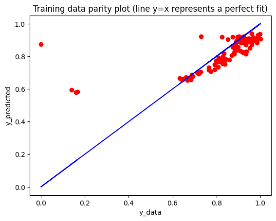

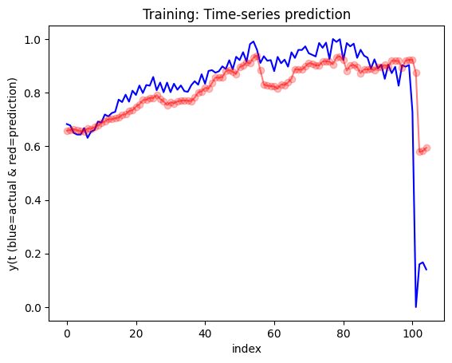

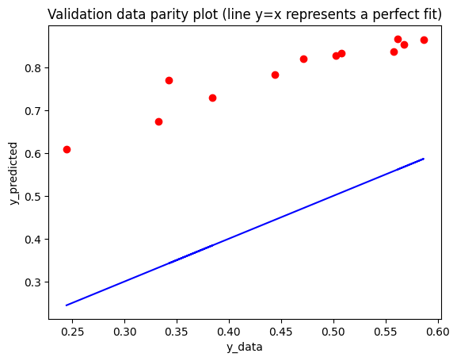

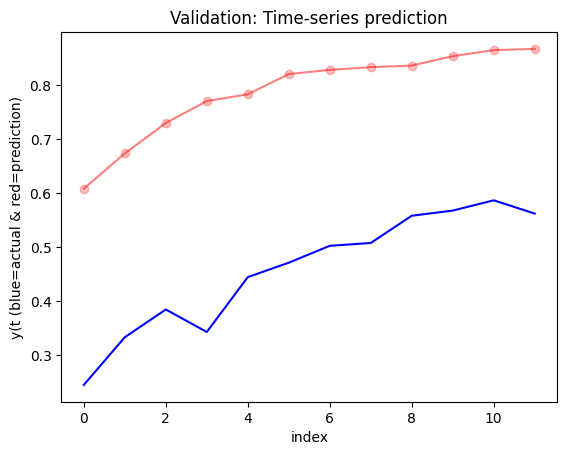

### Traditional Multivariate Models

The following code and output is a reiteration of what was completed in the Multivariate Time Series models section, where we fit an ARIMAX model with public transit ridership as the target variable and vehicle miles, unemployment rate, and gas prices. However, to better compare with deep learning techniques, this will use normalized data and the output will focus more greatly on the validation RMSE.

```r
df <- read.csv("../data/quarterly_combined.csv")
df <- df[,c("Total.Ridership..000s.", "vehicle_miles", "gas_prices", "unemployment_rate")]
normalize <- function(x) (x - min(x)) / (max(x) - min(x))
df_scaled <- as.data.frame(lapply(df, normalize))
n <- nrow(df_scaled)
val_size <- round(0.1 * n)

train <- df_scaled[1:(n - val_size), ]
val <- df_scaled[(n - val_size + 1):n, ]

y_train <- train$Total.Ridership..000s.
y_val <- val$Total.Ridership..000s.

xreg_train <- as.matrix(train[, c("vehicle_miles", "gas_prices", "unemployment_rate")])
xreg_val <- as.matrix(val[, c("vehicle_miles", "gas_prices", "unemployment_rate")])
```

```r
library(forecast)
fit <- auto.arima(y_train, xreg = xreg_train)
fc <- forecast(fit, xreg = xreg_val, h = val_size)
preds <- fc$mean
rmse <- sqrt(mean((y_val - preds)^2))
cat("Validation RMSE (ARIMAX):", round(rmse, 4), "\n")
```

```
Validation RMSE (ARIMAX): 0.1728
```

### RMSE Summary Table

This table provides a tidy comparison between the validation RMSE of deep learning models and traditional models. The traditional models have been adjusted to deal with the same normalized data, so simply comparing the RMSE values will allow us to make accurate conclusions.

| Model Type | Model | Input Type | RMSE |
| --- | --- | --- | --- |
| Traditional | ARIMA | Univariate | 0.2981 |
| Traditional | ARIMAX | Multivariate | 0.1728 |
| Deep Learning | RNN | Univariate | 0.0450 |
| Deep Learning | LSTM | Univariate | 0.1167 |
| Deep Learning | GRU | Univariate | **0.0436** |
| Deep Learning | RNN | Multivariate | 0.1399 |
| Deep Learning | LSTM | Multivariate | **0.1182** |
| Deep Learning | GRU | Multivariate | 0.3327 |

### Model Comparison Write-up

The table above offers interesting insight into which methods are most effective in forecasting public transit ridership data. Firstly, it is clear that deep learning has a greater impact using univariate input types, as that’s where we see the largest gulf in RMSE. However, both the simple RNN and the LSTM performed better than the SARIMAX model for multivariate data, indicating that it is still an applicable tool. Perhaps more importantly, all three deep learning models performed better with univariate inputs than multivariate inputs, indicating that the inclusion of exogenous variables does not seem to enhance predictions with deep learning. This is a departure from the comparison we see with traditional models, where the SARIMAX model performs better than the ARIMA model.

A potential takeaway from this juxtaposition is that the data is able to be learned in univariate form, meaning simply evaluating past ridership values can be effective for deep learning forecasts. However, SARIMAX is effective in modeling exogenous relationships, and given that there is some linear correlation between our exogenous variables due to all of them having a relatively stable trend that was interrupted by the same global event, it proved to be a useful model for this time series. Meanwhile, multivariate deep learning models may have learned from unnecessary feature due to the increased complexity, which could have diminished their effectiveness.

Given these results, I would most trust the univariate RNN and GRU for further forecasting. This is not only because of their vastly superior RMSE values, but also due to the findings that exogenous variables may be highly correlated with ridership, but are often insufficient in fully explaining ridership trends. Thus, it is reasonable to presume that deep learning models with a univariate input type provides the greatest balance between rigorously learning relationships and reducing unnecessary complexity for this dataset.